# **MATH 3190 Homework 1**

Due January 29, 2026  
Focus: Notes 1-3  
Total Points: 90 + 10 (Self-Critique Comment and Uploading to GitHub) = 100

Note that your homework should be completed in Quarto. You can just add your answers and code to this document in the appropriate part. The file should be rendered as an html document or pdf document (html is quicker to render and you will need an installation of LaTeX to render as a pdf). You will “turn in” this homework by uploading the files, the .qmd and output file, to your GitHub `Math_3190_Assignment` repository in the `Homework/Homework_1` directory. Make sure all supporting files (if there are any) are in this directory as well. You should use `git` and `Unix` commands in a terminal for this (i.e. don’t manually upload files to GitHub). In addition, you will submit just your html or pdf file on Canvas to unlock the solutions.

Don’t forget to also put a self-critique comment on Canvas indicating what you did correctly and incorrectly and include any questions you may have about the assignment after submitting the assignment and thoroughly looking through the solutions.

# Problem 1 (18 points)

In two different code chunks, write two functions called `gghist` and `ggbox`. The first code chunk is already given below, but you’ll need to add the second one. The `gghist` function should create a ggplot histogram of a variable that is given as a vector. The `ggbox` function should create a ggplot box plot when a single numeric vector is given or it should create side-by-side box plots if one numeric and one categorical variables are given. You can check if a vector is numeric with the `is.numeric()` function. Allow the user to indicate whether it should be horizontal or vertical box plots. Make sure you set `echo` and `eval` both to `true` for these code chunks. Also make sure to label the code chunks.

```r
# Put gghist function here.

library(ggplot2)

gghist <- function(x, bins = 30) {
  if (!is.numeric(x)) {
    stop("Input must be a numeric vector.")
  }

  df <- data.frame(x = x)

  ggplot(df, aes(x = x)) +
      geom_histogram(bins = bins, fill = "lightblue", color = "darkgreen") +
      labs(x = "Value", y = "Count") +
      theme_minimal()
}
```

```r
# Here is the ggbox function.

library(ggplot2)

ggbox <- function(x, group = NULL, horizontal = FALSE) {
  if (!is.numeric(x)) {
    stop("Input must be a numeric vector.")
  }

  # Case 1: single numeric vector
  if(is.null(group)) {
    df <-data.frame(x = x)

    p <- ggplot(df, aes(y = x)) +
      geom_boxplot(fill = "lavender") +
      labs(y = "Value") +
      theme_minimal()

    if (horizontal) {
      p <- p + coord_flip()
    }

    return(p)
  }

  # Case 2: numeric + categorical vector
  df <- data.frame(x = x, group = group)

  p <- ggplot(df, aes(x = group, y =x)) +
    geom_boxplot(fill = "lightyellow") +
    labs(x = "Group", y = "Value") +
    theme_minimal()

  if (horizontal) {
    p <- p + coord_flip()
  }

  p
}
```

# Problem 2 (57 points)

### Part a (6 points)

Learn about the built-in `read.fwf()` **R** function for use in downloading data from a URL into **R**. The `widths` and `strip.white` options will be especially useful here. Use this function to download the scores for all college basketball games for the 2024-2025 season http://kenpom.com/cbbga26.txt and then convert it to a tibble (load the `tidyverse` package first). The second team listed per line is the home team. It is not clear what the numbers, letters, or city names indicate after the second listed score. Notice that this is a “live” file that gets updated every day! So, your tibble size may change if you work on this assignment over the course of several days. That’s fine. Give the code you used to download these data in a labeled code chunk.

```r
library(tidyverse)
url <- "http://kenpom.com/cbbga26.txt"

cbb_raw <- read.fwf(file = url,
                    widths = c(10, 20, 3, 25, 50),
                    strip.white = TRUE)

cbb_scores <- as_tibble(cbb_raw)
```

Now lets practice using our tidy data/tidyverse tools! Using your `cbbga` tibble, try doing the following. In each part, save the object as a new tibble (like `cbbga2`, `cbbga3`, etc) and in each subsequent part, use the tibble you created in the previous part.

### Part b (2 points)

Use `rename()` to rename all of your variables to names that make sense. Then print the first six rows of the new tibble using the `head()` function.

```r
cbbga2 <- cbb_scores %>%
  rename(
   game_date = V1,
   away_school = V2,
   spacer = V3,
   away_score_and_home_school = V4,
   home_score_and_extra_info = V5
  )

head(cbbga2)
```

```
# A tibble: 6 × 5
  game_date  away_school   spacer away_score_and_home_s…¹ home_score_and_extra…²
  <chr>      <chr>         <chr>  <chr>                   <chr>
1 11/03/2025 McMurry       ""     55 Abilene Christian    92
2 11/03/2025 James Madison ""     71 Akron                85
3 11/03/2025 North Dakota  ""     62 Alabama              91
4 11/03/2025 Blue Mountain ""     60 Alabama A&M          80
5 11/03/2025 Florida       ""     87 Arizona              93 N   Las Vegas, NV
6 11/03/2025 Southern      ""     77 Arkansas             109
# ℹ abbreviated names: ¹away_score_and_home_school, ²home_score_and_extra_info
```

### Part c (2 points)

Use `mutate()` to create a new column that gives the score differences (home team score minus away team score). Then print the first six rows of the new tibble using the `head()` function.

```r
cbbga3 <- cbbga2 %>%
  mutate(
    away_score = as.numeric(str_extract(away_score_and_home_school, "^\\d+")),
    home_score = as.numeric(str_extract(home_score_and_extra_info, "\\d+")),
    score_difference = home_score - away_score
  )

head(cbbga3)
```

```
# A tibble: 6 × 8
  game_date  away_school   spacer away_score_and_home_s…¹ home_score_and_extra…²
  <chr>      <chr>         <chr>  <chr>                   <chr>
1 11/03/2025 McMurry       ""     55 Abilene Christian    92
2 11/03/2025 James Madison ""     71 Akron                85
3 11/03/2025 North Dakota  ""     62 Alabama              91
4 11/03/2025 Blue Mountain ""     60 Alabama A&M          80
5 11/03/2025 Florida       ""     87 Arizona              93 N   Las Vegas, NV
6 11/03/2025 Southern      ""     77 Arkansas             109
# ℹ abbreviated names: ¹away_score_and_home_school, ²home_score_and_extra_info
# ℹ 3 more variables: away_score <dbl>, home_score <dbl>,
#   score_difference <dbl>
```

### Part d (2 points)

Use `arrange()` to sort the data set by the home team alphabetically. Then print the first six rows of the new tibble using the `head()` function.

```r
cbbga4 <- cbbga3 %>%
  arrange(home_score_and_extra_info)

head(cbbga4)
```

```
# A tibble: 6 × 8
  game_date  away_school    spacer away_score_and_home_…¹ home_score_and_extra…²
  <chr>      <chr>          <chr>  <chr>                  <chr>
1 11/03/2025 Thomas ME      ""     48 Stonehill           100
2 11/03/2025 Oklahoma Chri… ""     57 Tulsa               100
3 11/05/2025 Southern       ""     82 Marquette           100
4 11/05/2025 Milligan       ""     51 Middle Tennessee    100
5 11/09/2025 East Texas A&M ""     74 Hawaii              100
6 11/12/2025 Coppin St.     ""     50 South Florida       100
# ℹ abbreviated names: ¹away_score_and_home_school, ²home_score_and_extra_info
# ℹ 3 more variables: away_score <dbl>, home_score <dbl>,
#   score_difference <dbl>
```

### Part e (2 points)

Use `select()` to remove the extra variable(s) that had that irrelevant information at the end of each line. Note: you can select every variable except one by using `!`. Then print the first six rows of the new tibble using the `head()` function.

```r
cbbga5 <- cbbga4 %>%
  select(!home_score_and_extra_info)

head(cbbga5)
```

```
# A tibble: 6 × 7
  game_date  away_school     spacer away_score_and_home_…¹ away_score home_score
  <chr>      <chr>           <chr>  <chr>                       <dbl>      <dbl>
1 11/03/2025 Thomas ME       ""     48 Stonehill                   48        100
2 11/03/2025 Oklahoma Chris… ""     57 Tulsa                       57        100
3 11/05/2025 Southern        ""     82 Marquette                   82        100
4 11/05/2025 Milligan        ""     51 Middle Tennessee            51        100
5 11/09/2025 East Texas A&M  ""     74 Hawaii                      74        100
6 11/12/2025 Coppin St.      ""     50 South Florida               50        100
# ℹ abbreviated name: ¹away_score_and_home_school
# ℹ 1 more variable: score_difference <dbl>
```

### Part f (3 points)

Put parts a-e all together in one piping expression (with 5 pipes) and save this as a new object in **R**.

```r
library(tidyverse)

url <- "http://kenpom.com/cbbga26.txt"

cbbga_final <- read.fwf(file = url,
                    widths = c(10, 20, 3, 25, 50),
                    strip.white = TRUE) %>%
  as_tibble() %>%
  rename(
    game_date = V1,
    away_school = V2,
    spacer = V3,
    away_score_and_home_school = V4,
    home_score_and_extra_info = V5
  ) %>%
  mutate(
    away_score = as.numeric(str_extract(away_score_and_home_school, "^\\d+")),
    home_score = as.numeric(str_extract(home_score_and_extra_info, "\\d+")),
    score_difference = home_score - away_score
  ) %>%
  arrange(home_score_and_extra_info) %>%
  select(game_date, away_school, away_score, home_score_and_extra_info,
         home_score, score_difference)

head(cbbga_final)
```

```
# A tibble: 6 × 6
  game_date  away_school        away_score home_score_and_extra_info home_score
  <chr>      <chr>                   <dbl> <chr>                          <dbl>
1 11/03/2025 Thomas ME                  48 100                              100
2 11/03/2025 Oklahoma Christian         57 100                              100
3 11/05/2025 Southern                   82 100                              100
4 11/05/2025 Milligan                   51 100                              100
5 11/09/2025 East Texas A&M             74 100                              100
6 11/12/2025 Coppin St.                 50 100                              100
# ℹ 1 more variable: score_difference <dbl>
```

### Part g (3 points)

Use `filter()` to reduce the data down to only games played in 2025 (you could use the `lubridate` package for this, since it specializes in dealing with dates, but some base **R** packages will also work). Save this in a new tibble. **We will use this tibble with only the 2025 years from here on out**.

```r
library(lubridate)

cbbga_2025 <- cbbga_final %>%
  mutate(game_date = mdy(game_date)) %>%
  filter(year(game_date) == 2025)

head(cbbga_2025)
```

```
# A tibble: 6 × 6
  game_date  away_school        away_score home_score_and_extra_info home_score
  <date>     <chr>                   <dbl> <chr>                          <dbl>
1 2025-11-03 Thomas ME                  48 100                              100
2 2025-11-03 Oklahoma Christian         57 100                              100
3 2025-11-05 Southern                   82 100                              100
4 2025-11-05 Milligan                   51 100                              100
5 2025-11-09 East Texas A&M             74 100                              100
6 2025-11-12 Coppin St.                 50 100                              100
# ℹ 1 more variable: score_difference <dbl>
```

### Part h (4 points)

Write a function that will filter the tibble to only games played by a given team. Demonstrate your function by displaying games played by SUU in 2025.

```r
library(tidyverse)

filter_team_games <- function(team, data) {
  data %>%
    filter(away_school == team | str_detect(home_score_and_extra_info, team))
}

suu_games <- filter_team_games("SUU", cbbga_2025)
```

### Part i (7 points)

```r
library(dplyr)
library(stringr)

suu_games <- suu_games %>%
  mutate(result = case_when(
  away_school == "SUU" & away_score > home_score ~ "Win",
  away_school == "SUU" & away_score < home_score ~ "Loss",
  str_detect(home_score_and_extra_info, "SUU") & home_score > away_score ~ "Win",
  str_detect(home_score_and_extra_info, "SUU") & home_score < away_score ~ "Loss",
  TRUE ~ NA_character_
))

suu_summary <- suu_games %>%
  summarize(
    wins = sum(result == "Win", na.rm = TRUE),
    losses = sum(result == "Loss", na.rm = TRUE),
    win_pct = wins / (wins + losses)
  )

suu_summary
```

```
# A tibble: 1 × 3
   wins losses win_pct
  <int>  <int>   <dbl>
1     0      0     NaN
```

### Part j (7 points)

Generalize this by writing a function that will do this for a given team, and create a tibble with this information for all teams. Arrange this tibble first by winning percentage (descending) and by team (alphabetically) if there are any ties when it comes to winning percentage. A `for` loop and the `add_row()` function may be useful here.

```r
library(dplyr)
library(stringr)
library(tibble)

team_record <- function(team, data) {
  team_games <- data %>%
    filter(away_school == team | str_detect(home_score_and_extra_info, team)) %>%
    mutate(result = case_when(
      away_school == team & away_score > home_score ~ "Win",
      away_school == team & away_score < home_score ~ "Loss",
      str_detect(home_score_and_extra_info, team) & home_score > away_score ~ "Win",
      str_detect(home_score_and_extra_info, team) & home_score < away_score ~ "Loss",
      TRUE ~ NA_character_
    ))

  team_summary <- team_games %>%
    summarize(
      team = team,
      wins = sum(result == "Win", na.rm = TRUE),
      losses = sum(result == "Loss", na.rm = TRUE),
      win_pct = wins / (wins + losses)
    )

  return(team_summary)
}

teams <- unique(c(cbbga_2025$away_school,
                  str_extract(cbbga_2025$home_score_and_extra_info,
                              "^[A-Za-z0-9 ]+")))

all_team_records <- tibble(
  team = character(),
  wins = numeric(),
  losses = numeric(),
  win_pct = numeric()
)

for (team in teams) {
  team_summary <- team_record(team, cbbga_2025)
  all_team_records <- add_row(all_team_records, team_summary)
}

all_team_records <- all_team_records %>%
  arrange(desc(win_pct), team)

all_team_records
```

```
# A tibble: 1,221 × 4
   team               wins losses win_pct
   <chr>             <dbl>  <dbl>   <dbl>
 1 100 N   Lahaina       1      0       1
 2 101 N   Las Vegas     1      0       1
 3 102                  33      0       1
 4 102 1                 1      0       1
 5 102 N   Lahaina       1      0       1
 6 103                  25      0       1
 7 104                  28      0       1
 8 104 N   San Diego     1      0       1
 9 105                  23      0       1
10 105 N   Las Vegas     1      0       1
# ℹ 1,211 more rows
```

### Part k (5 points)

With only the 2025 games, use the `gghist()` you wrote in Problem 1 on the score differences variable you created in part c. Add appropriate labels and a title to your graph. Also, use the `#| fig-width:`, `#| fig-height:`, `#| out-width:`, and `#| fig-align:` code chunk options to center the figure and then to adjust your figure to a size you like. Play around with different sizes to see what those options adjust.

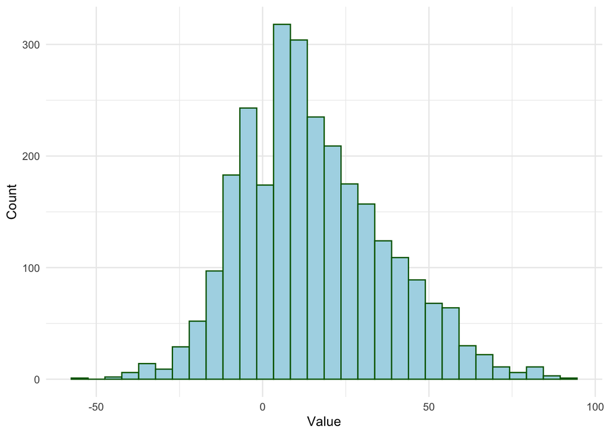

```r
gghist(cbbga_2025$score_difference)
```

### Part l (9 points)

Filter the tibble with all 2025 games to only include Utah Tech or Southern Utah, then crate a tibble or data frame where each row is a game played by either team that has one column indicating the school, Utah Tech or Southern Utah, and a second column indicating the number of points that team played, regardless of whether the team was home or away. Then use your `ggbox()` function to create a side-by-side boxplot of number of points scored in all 2025 games for each team.

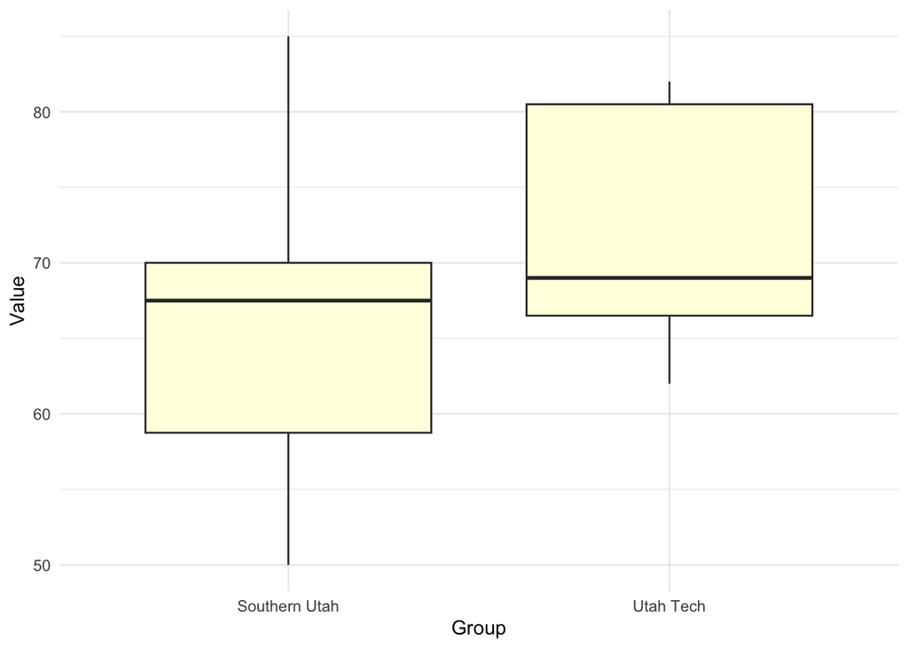

```r
library(dplyr)
library(stringr)

ut_suu_games <- cbbga_2025 %>%
  filter(away_school %in% c("Utah Tech", "Southern Utah") |
         str_detect(home_score_and_extra_info, "Utah Tech|Southern Utah"))

team_points <- ut_suu_games %>%
  transmute(school = away_school, points = away_score) %>%
  bind_rows(
    ut_suu_games %>%
      transmute(school = str_extract(home_score_and_extra_info, "^[A-Za-z0-9 ]+"),
                points = home_score)
  ) %>%
  filter(school %in% c("Utah Tech", "Southern Utah"))

ggbox(x = team_points$points, group = team_points$school, horizontal = FALSE)
```

Note, this is a little challenging. The most straightforward way to do this is to use the `pivot_longer()` function with `cols =` the names of the two columns that have the away and the home teams (the names of these columns should not be in quotes, but they should be in a vector `c()`). Try to do this yourself first, but using AI for some help is fine.

### Part m (5 points)

Create one more appropriate graphs for the 2025 basketball data. This graph could be anything you’d like as long as you use `ggplot2`, it shows something meaningful, and it is not the same as the graphs you made in parts k or l.

```r
library(dplyr)
library(tidyr)
library(ggplot2)
library(stringr)

scores_long <- cbbga_2025 %>%
  pivot_longer(
    cols = c(away_score, home_score),
    names_to = "home_or_away",
    values_to = "points"
  ) %>%
  mutate(team = ifelse(
    home_or_away == "away_score",
    away_school,
    str_extract(home_score_and_extra_info, "^[A-Za-z0-9 ]+")
  ))
```

[output not shown]

# Problem 3 (15 points)

Repeat parts b-e and g of Problem 2 using Python in Quarto. First, pass the original object that you read in from the website to Python without any changes to it (you do not need to read the file from the web in Python, but you can if you’d like) and then use `pandas` (or `polars` if you’d like) to rename the columns as indicated in part b, add the columns specified in part c, arrange the data as in part d, drop the “garbage” column as in part e, and filter it down as in part g. The `pandas` functions `rename`, `assign` (instead of `mutate`), `drop` (instead of `select`) and `str.contains` (used to select the right rows) will be useful here. Be sure to follow the guide in Notes 3 to properly install Python, install the `pandas` library and to load it in **R**.

```python
import pandas as pd

cbb_scores_py = r.cbb_scores

cbb_scores_py = cbb_scores_py.rename(columns={
  'V1': 'game_date',
  'V2': 'away_school',
  'V3': 'spacer',
  'V4': 'away_score_and_home_school',
  'V5': 'home_score_and_extra_info'
})


cbb_scores_py['away_score'] = cbb_scores_py['away_score_and_home_school'].str.extract(r'(\d+)').astype(int)
cbb_scores_py['home_score'] = cbb_scores_py['home_score_and_extra_info'].str.extract(r'(\d+)').astype(int)
cbb_scores_py['score_difference'] = cbb_scores_py['home_score'] - cbb_scores_py['away_score']

cbb_scores_py = cbb_scores_py.sort_values(by='home_score_and_extra_info')

cbb_scores_py = cbb_scores_py.drop(columns=['spacer'])

cbb_scores_py['game_date'] = pd.to_datetime(cbb_scores_py['game_date'],
format='%m/%d/%Y')
cbb_2025_py = cbb_scores_py[cbb_scores_py['game_date'].dt.year == 2025]

cbb_2025_py.head()
```

```
      game_date         away_school  ... home_score score_difference
1299 2025-11-25      Rutgers Camden  ...        100               39
2395 2025-12-20             Lourdes  ...        100               33
1037 2025-11-21             Niagara  ...        100               58
1019 2025-11-20       Ohio Wesleyan  ...        100               53
136  2025-11-03  Oklahoma Christian  ...        100               43

[5 rows x 7 columns]
```

[output not shown]